# 重賞レース予測レポート【毎時自動更新中】

作成日時: 2026/08/23 15:05:42

☞ [マニュアル(pdf)](https://ryutoro-galois.github.io/keiba-predictor/manual/manual.pdf)

☞ 過去6年の同一レース結果: [2025年](https://ryutoro-galois.github.io/keiba-predictor/report/PredResult_2025y_raceDate_20250824_20250824.html), [2024年](https://ryutoro-galois.github.io/keiba-predictor/report/PredResult_2024y_raceDate_20240818_20240818.html), [2023年](https://ryutoro-galois.github.io/keiba-predictor/report/PredResult_2023y_raceDate_20230820_20230820.html), [2022年](https://ryutoro-galois.github.io/keiba-predictor/report/PredResult_2022y_raceDate_20220821_20220821.html), [2021年](https://ryutoro-galois.github.io/keiba-predictor/report/PredResult_2021y_raceDate_20210822_20210822.html), [2020年](https://ryutoro-galois.github.io/keiba-predictor/report/PredResult_2020y_raceDate_20200823_20200823.html)

☞ 過去4週間の別レース結果: [1週前(8/15-16)](https://ryutoro-galois.github.io/keiba-predictor/report/PredResult_2026y_raceDate_20260815_20260816.html), [2週前(8/8-9)](https://ryutoro-galois.github.io/keiba-predictor/report/PredResult_2026y_raceDate_20260808_20260809.html), [3週前(8/2)](https://ryutoro-galois.github.io/keiba-predictor/report/PredResult_2026y_raceDate_20260802_20260802.html), [4週前(7/26)](https://ryutoro-galois.github.io/keiba-predictor/report/PredResult_2026y_raceDate_20260726_20260726.html)

## 0. 推し馬予測 (AI予測)

### 【新潟2歳ステークス(GⅢ) 2026/08/23(日)】

- 本命(◎): 1-3着内確率(勝負強さ)が1位の馬
- 対抗(◯): 1-3着内確率が2-N位(20%程度以上)の中で予測タイムが最も速い馬
- 3番手(▲): 1-3着内確率が2-N位(20%程度以上)のでダークホース確率が最も高い馬
- 穴: ダークホース確率が上位1-M位(40%程度以上)の中で1-3着内確率が最も高い馬

| 推し馬 | 枠番 | 馬番 | 人気 | オッズ | 馬名 | 騎手 | 調教師 | 予測タイム(sec) | 1_順位 | 1-3着内確率(%) | 2_順位 | ﾀﾞｰｸﾎｰｽ確率(%) | 3_順位 |
| --- | --- | --- | --- | --- | --- | --- | --- | --- | --- | --- | --- | --- | --- |
| 本命(◎) | 7 | 7 | 3 | 4.0 | トウシンマジック | Ｊ．コレット | 秋本大介 | 98.0 | 4 | 60.2 | 1 | 0.4 | 10 |
| 対抗(◯) | 2 | 2 | 1 | 3.5 | レッチュベルク | 田辺裕信 | 久保田貴士 | 93.4 | 1 | 22.6 | 4 | 0.4 | 8 |
| 穴 | 4 | 4 | 10 | 98.0 | アイデアルカット | 嶋田純次 | 手塚貴徳 | 106.2 | 9 | 6.8 | 7 | 48.3 | 1 |

### 【キーンランドカップ(GⅢ) 2026/08/23(日)】

- 本命(◎): 1-3着内確率(勝負強さ)が1位の馬
- 対抗(◯): 1-3着内確率が2-N位(20%程度以上)の中で予測タイムが最も速い馬
- 3番手(▲): 1-3着内確率が2-N位(20%程度以上)のでダークホース確率が最も高い馬
- 穴: ダークホース確率が上位1-M位(40%程度以上)の中で1-3着内確率が最も高い馬

| 推し馬 | 枠番 | 馬番 | 人気 | オッズ | 馬名 | 騎手 | 調教師 | 予測タイム(sec) | 1_順位 | 1-3着内確率(%) | 2_順位 | ﾀﾞｰｸﾎｰｽ確率(%) | 3_順位 |
| --- | --- | --- | --- | --- | --- | --- | --- | --- | --- | --- | --- | --- | --- |
| 本命(◎) | 4 | 8 | 3 | 10.1 | ウインカーネリアン | 三浦皇成 | 鹿戸雄一 | 78.2 | 12 | 24.3 | 1 | 1.1 | 9 |
| 対抗(◯) | 2 | 3 | 1 | 2.0 | パンジャタワー | 松山弘平 | 橋口慎介 | 67.6 | 1 | 21.6 | 3 | 0.4 | 14 |
| 3番手(▲) | 1 | 1 | 7 | 17.0 | ナムラクララ | 浜中俊 | 長谷川浩大 | 70.8 | 7 | 22.2 | 2 | 1.4 | 7 |
| 穴 | 3 | 6 | 14 | 98.8 | ジョーメッドヴィン | 吉村智洋 | 清水久詞 | 69.9 | 4 | 12.1 | 7 | 44.2 | 1 |

## 1. 予測チャート (タイム/勝負強さ)

### 【新潟2歳ステークス(GⅢ)】

2026/08/23(日), 04_新潟, 芝左外1600m

[interactive chart not shown]

### 【キーンランドカップ(GⅢ)】

2026/08/23(日), 01_札幌, 芝右1200m

[interactive chart not shown]

## 2. オッズモニタリング (毎時)

### 【新潟2歳ステークス】

[interactive chart not shown]

### 【キーンランドカップ】

[interactive chart not shown]

## 3. 出馬表

### 【新潟2歳ステークス 2026/08/23(日) 】

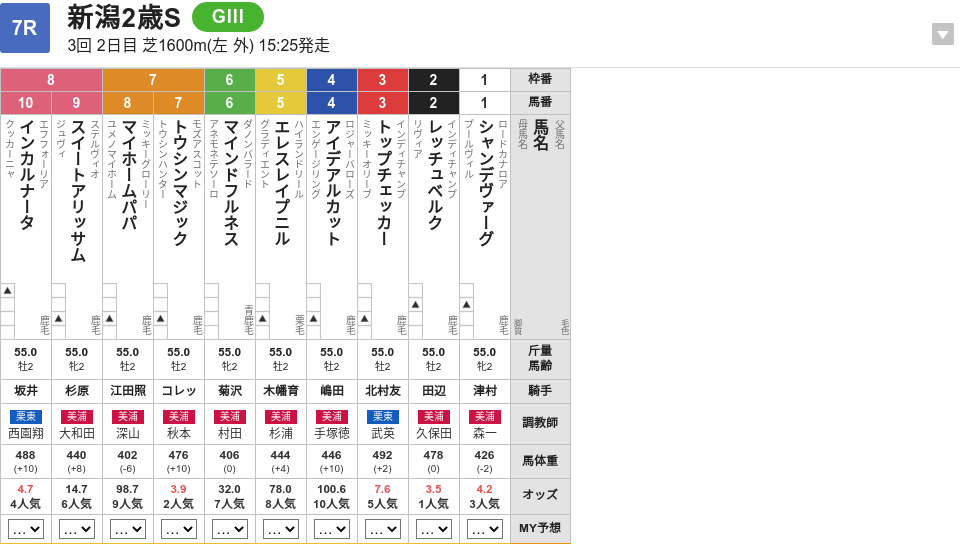

### 【キーンランドカップ 2026/08/23(日) 】

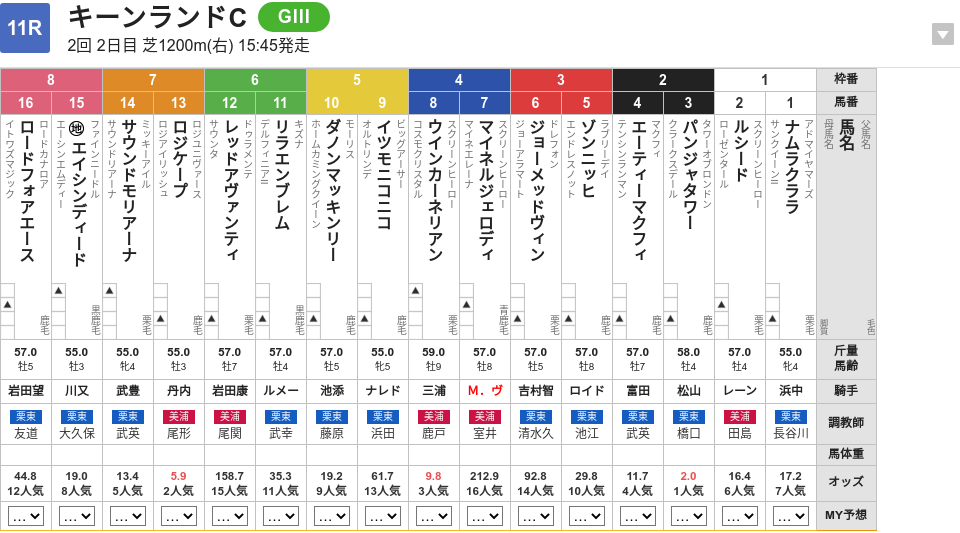

## 4. 単勝予測結果

### 【新潟2歳ステークス(GⅢ) 2026/08/23(日)】

| 枠番 | 馬番 | 人気 | オッズ | 馬名 | 騎手 | 調教師 | 予測タイム(sec) | 1_順位 | 1-3着内確率(%) | 2_順位 | ﾀﾞｰｸﾎｰｽ確率(%) | 3_順位 |
| --- | --- | --- | --- | --- | --- | --- | --- | --- | --- | --- | --- | --- |
| 1 | 1 | 2 | 4.0 | シャンデヴァーグ | 津村明秀 | 森一誠 | 97.2 | 2 | 50.5 | 2 | 0.4 | 7 |
| 2 | 2 | 1 | 3.5 | レッチュベルク | 田辺裕信 | 久保田貴士 | 93.4 | 1 | 22.6 | 4 | 0.4 | 8 |
| 3 | 3 | 5 | 7.6 | トップチェッカー | 北村友一 | 武英智 | 98.0 | 5 | 18.5 | 5 | 1.1 | 6 |
| 4 | 4 | 10 | 98.0 | アイデアルカット | 嶋田純次 | 手塚貴徳 | 106.2 | 9 | 6.8 | 7 | 48.3 | 1 |
| 5 | 5 | 8 | 74.7 | エレスレイプニル | 木幡育也 | 杉浦宏昭 | 106.8 | 10 | 2.8 | 10 | 16.2 | 4 |
| 6 | 6 | 7 | 32.6 | マインドフルネス | 菊沢一樹 | 村田一誠 | 97.5 | 3 | 9.1 | 6 | 31.8 | 3 |
| 7 | 7 | 3 | 4.0 | トウシンマジック | Ｊ．コレット | 秋本大介 | 98.0 | 4 | 60.2 | 1 | 0.4 | 10 |
| 7 | 8 | 9 | 93.3 | マイホームパパ | 江田照男 | 深山雅史 | 105.5 | 7 | 3.6 | 9 | 13.2 | 5 |
| 8 | 9 | 6 | 14.8 | スイートアリッサム | 杉原誠人 | 大和田成 | 106.1 | 8 | 6.8 | 8 | 34.2 | 2 |
| 8 | 10 | 4 | 4.7 | インカルナータ | 坂井瑠星 | 西園翔太 | 98.6 | 6 | 34.3 | 3 | 0.4 | 9 |

### 【キーンランドカップ(GⅢ) 2026/08/23(日)】

| 枠番 | 馬番 | 人気 | オッズ | 馬名 | 騎手 | 調教師 | 予測タイム(sec) | 1_順位 | 1-3着内確率(%) | 2_順位 | ﾀﾞｰｸﾎｰｽ確率(%) | 3_順位 |
| --- | --- | --- | --- | --- | --- | --- | --- | --- | --- | --- | --- | --- |
| 1 | 1 | 7 | 17.0 | ナムラクララ | 浜中俊 | 長谷川浩大 | 70.8 | 7 | 22.2 | 2 | 1.4 | 7 |
| 1 | 2 | 6 | 16.7 | ルシード | Ｄ．レーン | 田島俊明 | 78.1 | 11 | 7.6 | 14 | 0.8 | 12 |
| 2 | 3 | 1 | 2.0 | パンジャタワー | 松山弘平 | 橋口慎介 | 67.6 | 1 | 21.6 | 3 | 0.4 | 14 |
| 2 | 4 | 4 | 11.8 | エーティーマクフィ | 富田暁 | 武英智 | 77.7 | 10 | 11.7 | 9 | 1.1 | 10 |
| 3 | 6 | 14 | 98.8 | ジョーメッドヴィン | 吉村智洋 | 清水久詞 | 69.9 | 4 | 12.1 | 7 | 44.2 | 1 |
| 4 | 7 | 16 | 217.7 | マイネルジェロディ | Ｍ．ヴェロン | 室井潔 | 76.8 | 9 | 11.8 | 8 | 19.4 | 6 |
| 4 | 8 | 3 | 10.1 | ウインカーネリアン | 三浦皇成 | 鹿戸雄一 | 78.2 | 12 | 24.3 | 1 | 1.1 | 9 |
| 5 | 10 | 9 | 19.1 | ダノンマッキンリー | 池添謙一 | 藤原英昭 | 69.4 | 2 | 15.1 | 5 | 26.1 | 5 |
| 6 | 11 | 11 | 35.7 | リラエンブレム | Ｃ．ルメール | 武幸四郎 | 70.2 | 5 | 8.5 | 13 | 34.8 | 3 |
| 6 | 12 | 15 | 158.8 | レッドアヴァンティ | 岩田康誠 | 尾関知人 | 69.6 | 3 | 10.3 | 11 | 41.4 | 2 |

[output cut: 4 more lines]

## 5. 人気と着順の乖離率推移

### 【新潟2歳ステークス_2001y_2019y】

[interactive chart not shown]

### 【キーンランドカップ_2006y_2019y】

[interactive chart not shown]

### 【新潟2歳ステークス_2001y_2019y】

| No | 開催年 | 不整合率(%) | 頭数 | 人気別着順(1-3位) | 人気別着順(全体) |
| --- | --- | --- | --- | --- | --- |
| 19 | 2019 | 32.9 | 16頭 | 1-3-8 | 1\|3\|8\|7\|5\|12\|6\|2\|13\|11\|9\|16\|4\|14\|15\|10 |
| 18 | 2018 | 5.2 | 11頭 | 1-2-8 | 1\|2\|8\|3\|4\|5\|9\|10\|6\|7\|11 |
| 17 | 2017 | 58.7 | 15頭 | 3-5-2 | 3\|5\|2\|11\|14\|6\|4\|10\|7\|15\|12\|1\|9\|13\|8 |
| 16 | 2016 | 55.8 | 15頭 | 3-6-2 | 3\|6\|2\|8\|4\|12\|5\|1\|14\|10\|9\|7\|13\|11\|15 |
| 15 | 2015 | 24.3 | 18頭 | 1-12-8 | 1\|12\|8\|5\|10\|2\|17\|3\|6\|16\|9\|11\|7\|13\|15\|18\|4\|14 |
| 14 | 2014 | 37.1 | 18頭 | 3-1-6 | 3\|1\|6\|12\|5\|2\|10\|4\|14\|7\|16\|13\|8\|11\|9\|17\|15\|18 |
| 13 | 2013 | 37.5 | 18頭 | 1-4-6 | 1\|4\|6\|14\|5\|10\|3\|7\|2\|9\|15\|13\|11\|18\|16\|8\|12\|17 |
| 12 | 2012 | 41.0 | 18頭 | 3-10-9 | 3\|10\|9\|1\|2\|12\|14\|15\|6\|8\|18\|5\|4\|13\|17\|16\|7\|11 |
| 11 | 2011 | 33.5 | 18頭 | 4-1-9 | 4\|1\|9\|2\|8\|13\|17\|6\|12\|5\|14\|16\|10\|18\|7\|3\|15\|11 |
| 10 | 2010 | 56.6 | 17頭 | 9-10-5 | 9\|10\|5\|4\|11\|6\|8\|2\|14\|1\|12\|3\|17\|7\|13\|16\|15 |

[output cut: 9 more lines]

### 【キーンランドカップ_2006y_2019y】

| No | 開催年 | 不整合率(%) | 頭数 | 人気別着順(1-3位) | 人気別着順(全体) |
| --- | --- | --- | --- | --- | --- |
| 14 | 2019 | 5.8 | 16頭 | 1-2-3 | 1\|2\|3\|11\|4\|5\|13\|6\|15\|8\|9\|10\|14\|12\|16\|7 |
| 13 | 2018 | 24.9 | 16頭 | 1-4-9 | 1\|4\|9\|5\|14\|2\|6\|7\|3\|16\|13\|10\|12\|8\|11\|15 |
| 12 | 2017 | 38.1 | 13頭 | 12-2-5 | 12\|2\|5\|11\|13\|1\|4\|10\|6\|9\|7\|8\|3 |
| 11 | 2016 | 18.4 | 14頭 | 2-1-3 | 2\|1\|3\|4\|9\|6\|8\|5\|13\|10\|14\|7\|11\|12 |
| 10 | 2015 | 28.3 | 16頭 | 8-9-1 | 8\|9\|1\|4\|2\|6\|5\|11\|3\|10\|12\|7\|15\|16\|13\|14 |
| 9 | 2014 | 37.5 | 16頭 | 3-1-5 | 3\|1\|5\|9\|7\|8\|2\|4\|10\|6\|12\|11\|15\|16\|13\|14 |
| 8 | 2013 | 34.6 | 15頭 | 4-1-6 | 4\|1\|6\|2\|10\|14\|7\|13\|16\|9\|8\|12\|5\|3\|15 |
| 7 | 2012 | 36.6 | 14頭 | 3-1-4 | 3\|1\|4\|5\|7\|10\|2\|6\|8\|11\|14\|13\|12\|9 |
| 6 | 2011 | 33.6 | 16頭 | 1-6-4 | 1\|6\|4\|7\|13\|12\|8\|5\|2\|10\|9\|16\|14\|3\|11\|15 |
| 5 | 2010 | 32.4 | 16頭 | 2-6-8 | 2\|6\|8\|1\|4\|7\|10\|3\|13\|5\|12\|11\|9\|15\|14\|16 |

[output cut: 4 more lines]

## 6. 1-3番人気馬の着順分類予測

### 【新潟2歳ステークス】

| 分類 | 凡例 | 発生確率(%) | 当該レース | 当該レースランク | 直近1年間 |
| --- | --- | --- | --- | --- | --- |
| 1: 1番人気のみ (1_pop1) | 1 \| * \| * | 18.4 | 0.77 | 0.83 | 0.00 |
| 4: 1,2番人気のみ (4_pop12) | 1 \| 2 \| * | 17.6 | 1.10 | 1.13 | 0.00 |
| 5: 1,3番人気のみ (5_pop13) | 1 \| 3 \| * | 16.4 | 0.46 | 0.67 | 0.33 |
| 8: 1,2,3番人気すべて着外 (8_darkhorse) | * \| * \| * | 13.8 | 1.73 | 2.06 | 0.00 |
| 6: 2,3番人気のみ (6_pop23) | 2 \| 3 \| * | 9.8 | 1.23 | 1.46 | 0.00 |
| 2: 2番人気のみ (2_pop2) | 2 \| * \| * | 9.1 | 0.00 | 4.14 | 0.00 |
| 3: 3番人気のみ (3_pop3) | 3 \| * \| * | 8.0 | 2.00 | 3.64 | 0.00 |
| 7: 1,2,3番人気すべて着内 (7_pop123) | 1 \| 2 \| 3 | 6.9 | 1.73 | 0.35 | 0.14 |

### 【キーンランドカップ】

| 分類 | 凡例 | 発生確率(%) | 当該レース | 当該レースランク | 直近1年間 |
| --- | --- | --- | --- | --- | --- |
| 1: 1番人気のみ (1_pop1) | 1 \| * \| * | 18.2 | 0.91 | 0.82 | 0.00 |
| 4: 1,2番人気のみ (4_pop12) | 1 \| 2 \| * | 17.8 | 1.19 | 1.14 | 0.00 |
| 8: 1,2,3番人気すべて着外 (8_darkhorse) | * \| * \| * | 13.8 | 2.76 | 2.06 | 0.00 |
| 5: 1,3番人気のみ (5_pop13) | 1 \| 3 \| * | 13.0 | 1.30 | 0.53 | 0.26 |
| 7: 1,2,3番人気すべて着内 (7_pop123) | 1 \| 2 \| 3 | 10.0 | 0.25 | 0.50 | 0.20 |
| 6: 2,3番人気のみ (6_pop23) | 2 \| 3 \| * | 9.8 | 1.96 | 1.46 | 0.00 |
| 2: 2番人気のみ (2_pop2) | 2 \| * \| * | 9.1 | 1.82 | 4.14 | 0.00 |
| 3: 3番人気のみ (3_pop3) | 3 \| * \| * | 8.2 | 0.00 | 3.73 | 0.00 |

## 7. 3連複予測結果

### 【新潟2歳ステークス(GⅢ) 2026/08/23(日)】

| 分類 | 馬番 | 枠番 | 人気 | 平均予測タイム(sec) | 1-3着内確率(%) | ﾀﾞｰｸﾎｰｽ確率(%) | 馬名 | 騎手 | 調教師 |
| --- | --- | --- | --- | --- | --- | --- | --- | --- | --- |
| 6: 2,3番人気のみ (6_pop23) | 1-7-10 | 1-7-8 | 2-3-4 | 97.93 | 10.42 | 0.00 | シャンデヴァーグ \| トウシンマジック \| インカルナータ | 津村明秀 \| Ｊ．コレット \| 坂井瑠星 | 森一誠 \| 秋本大介 \| 西園翔太 |
| 7: 1,2,3番人気すべて着内 (7_pop123) | 2-1-7 | 2-1-7 | 1-2-3 | 96.20 | 6.87 | 0.00 | レッチュベルク \| シャンデヴァーグ \| トウシンマジック | 田辺裕信 \| 津村明秀 \| Ｊ．コレット | 久保田貴士 \| 森一誠 \| 秋本大介 |
| 6: 2,3番人気のみ (6_pop23) | 1-7-3 | 1-7-3 | 2-3-5 | 97.73 | 5.63 | 0.00 | シャンデヴァーグ \| トウシンマジック \| トップチェッカー | 津村明秀 \| Ｊ．コレット \| 北村友一 | 森一誠 \| 秋本大介 \| 武英智 |
| 5: 1,3番人気のみ (5_pop13) | 2-7-10 | 2-7-8 | 1-3-4 | 96.67 | 4.67 | 0.00 | レッチュベルク \| トウシンマジック \| インカルナータ | 田辺裕信 \| Ｊ．コレット \| 坂井瑠星 | 久保田貴士 \| 秋本大介 \| 西園翔太 |
| 4: 1,2番人気のみ (4_pop12) | 2-1-10 | 2-1-8 | 1-2-4 | 96.40 | 3.92 | 0.00 | レッチュベルク \| シャンデヴァーグ \| インカルナータ | 田辺裕信 \| 津村明秀 \| 坂井瑠星 | 久保田貴士 \| 森一誠 \| 西園翔太 |
| 3: 3番人気のみ (3_pop3) | 7-10-3 | 7-8-3 | 3-4-5 | 98.20 | 3.82 | 0.00 | トウシンマジック \| インカルナータ \| トップチェッカー | Ｊ．コレット \| 坂井瑠星 \| 北村友一 | 秋本大介 \| 西園翔太 \| 武英智 |
| 2: 2番人気のみ (2_pop2) | 1-10-3 | 1-8-3 | 2-4-5 | 97.93 | 3.21 | 0.00 | シャンデヴァーグ \| インカルナータ \| トップチェッカー | 津村明秀 \| 坂井瑠星 \| 北村友一 | 森一誠 \| 西園翔太 \| 武英智 |
| 6: 2,3番人気のみ (6_pop23) | 1-7-6 | 1-7-6 | 2-3-7 | 97.57 | 2.77 | 0.00 | シャンデヴァーグ \| トウシンマジック \| マインドフルネス | 津村明秀 \| Ｊ．コレット \| 菊沢一樹 | 森一誠 \| 秋本大介 \| 村田一誠 |
| 5: 1,3番人気のみ (5_pop13) | 2-7-3 | 2-7-3 | 1-3-5 | 96.47 | 2.52 | 0.00 | レッチュベルク \| トウシンマジック \| トップチェッカー | 田辺裕信 \| Ｊ．コレット \| 北村友一 | 久保田貴士 \| 秋本大介 \| 武英智 |
| 4: 1,2番人気のみ (4_pop12) | 2-1-3 | 2-1-3 | 1-2-5 | 96.20 | 2.12 | 0.00 | レッチュベルク \| シャンデヴァーグ \| トップチェッカー | 田辺裕信 \| 津村明秀 \| 北村友一 | 久保田貴士 \| 森一誠 \| 武英智 |

[output cut: 110 more lines]

### 【キーンランドカップ(GⅢ) 2026/08/23(日)】

| 分類 | 馬番 | 枠番 | 人気 | 平均予測タイム(sec) | 1-3着内確率(%) | ﾀﾞｰｸﾎｰｽ確率(%) | 馬名 | 騎手 | 調教師 |
| --- | --- | --- | --- | --- | --- | --- | --- | --- | --- |
| 5: 1,3番人気のみ (5_pop13) | 3-8-1 | 2-4-1 | 1-3-7 | 72.20 | 1.16 | 0.00 | パンジャタワー \| ウインカーネリアン \| ナムラクララ | 松山弘平 \| 三浦皇成 \| 浜中俊 | 橋口慎介 \| 鹿戸雄一 \| 長谷川浩大 |
| 3: 3番人気のみ (3_pop3) | 8-1-15 | 4-1-8 | 3-7-8 | 73.23 | 0.82 | 0.00 | ウインカーネリアン \| ナムラクララ \| エイシンディード | 三浦皇成 \| 浜中俊 \| 川又賢治 | 鹿戸雄一 \| 長谷川浩大 \| 大久保龍志 |
| 3: 3番人気のみ (3_pop3) | 8-1-10 | 4-1-5 | 3-7-9 | 72.80 | 0.81 | 0.00 | ウインカーネリアン \| ナムラクララ \| ダノンマッキンリー | 三浦皇成 \| 浜中俊 \| 池添謙一 | 鹿戸雄一 \| 長谷川浩大 \| 藤原英昭 |
| 5: 1,3番人気のみ (5_pop13) | 3-8-15 | 2-4-8 | 1-3-8 | 72.17 | 0.80 | 0.00 | パンジャタワー \| ウインカーネリアン \| エイシンディード | 松山弘平 \| 三浦皇成 \| 川又賢治 | 橋口慎介 \| 鹿戸雄一 \| 大久保龍志 |
| 6: 2,3番人気のみ (6_pop23) | 13-8-1 | 7-4-1 | 2-3-7 | 74.63 | 0.80 | 0.00 | ロジケープ \| ウインカーネリアン \| ナムラクララ | 丹内祐次 \| 三浦皇成 \| 浜中俊 | 尾形和幸 \| 鹿戸雄一 \| 長谷川浩大 |
| 5: 1,3番人気のみ (5_pop13) | 3-8-10 | 2-4-5 | 1-3-9 | 71.73 | 0.79 | 0.00 | パンジャタワー \| ウインカーネリアン \| ダノンマッキンリー | 松山弘平 \| 三浦皇成 \| 池添謙一 | 橋口慎介 \| 鹿戸雄一 \| 藤原英昭 |
| 7: 1,2,3番人気すべて着内 (7_pop123) | 3-13-8 | 2-7-4 | 1-2-3 | 73.57 | 0.78 | 0.00 | パンジャタワー \| ロジケープ \| ウインカーネリアン | 松山弘平 \| 丹内祐次 \| 三浦皇成 | 橋口慎介 \| 尾形和幸 \| 鹿戸雄一 |
| 1: 1番人気のみ (1_pop1) | 3-1-15 | 2-1-8 | 1-7-8 | 69.70 | 0.73 | 0.00 | パンジャタワー \| ナムラクララ \| エイシンディード | 松山弘平 \| 浜中俊 \| 川又賢治 | 橋口慎介 \| 長谷川浩大 \| 大久保龍志 |
| 1: 1番人気のみ (1_pop1) | 3-1-10 | 2-1-5 | 1-7-9 | 69.27 | 0.73 | 0.00 | パンジャタワー \| ナムラクララ \| ダノンマッキンリー | 松山弘平 \| 浜中俊 \| 池添謙一 | 橋口慎介 \| 長谷川浩大 \| 藤原英昭 |
| 4: 1,2番人気のみ (4_pop12) | 3-13-1 | 2-7-1 | 1-2-7 | 71.10 | 0.72 | 0.00 | パンジャタワー \| ロジケープ \| ナムラクララ | 松山弘平 \| 丹内祐次 \| 浜中俊 | 橋口慎介 \| 尾形和幸 \| 長谷川浩大 |

[output cut: 210 more lines]

## 8. 直近の全レース情報

| No | 日付 | 競馬場 | R | 発走 | レース名 | 距離 | 頭数 | URL(netkeiba) |
| --- | --- | --- | --- | --- | --- | --- | --- | --- |
| 37 | 2026/08/23(日) | 04_新潟 | 1R |  | 2歳未勝利 | 1400 | 13頭 | https://race.netkeiba.com/race/shutuba.html?race_id=202604030201&amp;rf=race_list |
| 38 | 2026/08/23(日) | 04_新潟 | 2R |  | 2歳新馬 | 2000 | 9頭 | https://race.netkeiba.com/race/shutuba.html?race_id=202604030202&amp;rf=race_list |
| 39 | 2026/08/23(日) | 04_新潟 | 3R |  | 2歳新馬 | 1600 | 13頭 | https://race.netkeiba.com/race/shutuba.html?race_id=202604030203&amp;rf=race_list |
| 40 | 2026/08/23(日) | 04_新潟 | 4R |  | 3歳未勝利 | 1200 | 16頭 | https://race.netkeiba.com/race/shutuba.html?race_id=202604030204&amp;rf=race_list |
| 41 | 2026/08/23(日) | 04_新潟 | 5R |  | 3歳未勝利 | 1800 | 14頭 | https://race.netkeiba.com/race/shutuba.html?race_id=202604030205&amp;rf=race_list |
| 42 | 2026/08/23(日) | 04_新潟 | 6R | 14:50 | 古町S | 1800 | 18頭 | https://race.netkeiba.com/race/shutuba.html?race_id=202604030206&amp;rf=race_list |
| 43 | 2026/08/23(日) | 04_新潟 | 7R | 15:25 | 新潟2歳ステークス | 1600 | 10頭 | https://race.netkeiba.com/race/shutuba.html?race_id=202604030207&amp;rf=race_list |
| 44 | 2026/08/23(日) | 04_新潟 | 8R | 16:00 | 飯豊特別 | 1400 | 14頭 | https://race.netkeiba.com/race/shutuba.html?race_id=202604030208&amp;rf=race_list |
| 45 | 2026/08/23(日) | 04_新潟 | 9R |  | 3歳以上1勝クラス | 1200 | 18頭 | https://race.netkeiba.com/race/shutuba.html?race_id=202604030209&amp;rf=race_list |
| 46 | 2026/08/23(日) | 04_新潟 | 10R |  | 3歳以上1勝クラス | 2000 | 11頭 | https://race.netkeiba.com/race/shutuba.html?race_id=202604030210&amp;rf=race_list |

[output cut: 26 more lines]